# Análisis con Lenguaje R de datos del Fútbol Argentino, Primera Etapa

Ervar Luis M⚽lina

2024-08-21

# Introducción

Las apuestas digitales en el ámbito del fútbol argentino han experimentado un crecimiento exponencial en los últimos años, ofreciendo a los simpatizantes y a curiosos, una nueva dimensión de emoción y participación en este evento deportivo. Dicho fenómeno ha llevado a muchos entusiastas a explorar estrategias para mejorar sus posibilidades de éxito en las apuestas, y una de las aproximaciones más intrigantes que se proponen en este proyecto.

El primer objetivo de esta propuesta se centra en acondicionar el data set y establer una exploración de datos primaria para descubir métricas que en un proyecto futuro, puedan fomentar la posibilidad de estudiar con mas profundidad la relación entre las variables y el resultado de los partido. En una segunda etapa se crearía un modelo de machine learning que ayude a predecir resultados con una precisión estadísticamente considerable y así considerar si su rendimiento logra cierta efectividad científica para utilizarlo.

## Vista variables data set y sus tipos

```
## # A tibble: 6 × 34
##   torneo fecha partido equipo_local equipo_visitante goles_local goles_visitante
##   <chr>  <dbl>   <dbl> <chr>        <chr>                  <dbl>           <dbl>
## 1 Campe…     1       1 Velez        Aldosivi                   2               0
## 2 Campe…     1       2 Racing Club  Rosario Central            0               1
## 3 Campe…     1       3 San Lorenzo  Colon                      2               0
## 4 Campe…     1       4 Gimnasia (L… Def y Justicia             0               1
## 5 Campe…     1       5 Godoy Cruz   San Martin (SJ)            1               1
## 6 Campe…     1       6 Newells      Independiente              2               3
## # ℹ 27 more variables: posesion_local <dbl>, tiros_arco_local <dbl>,
## #   intentos_local <dbl>, faltas_local <dbl>, tiro_esquina_local <dbl>,
## #   posesion_visitante <dbl>, tiros_arco_visitante <dbl>,
## #   intentos_visitante <dbl>, faltas_visitante <dbl>,
## #   tiro_esquina_visitante <dbl>, amarillas_local <dbl>,
## #   amarillas_visitante <dbl>, rojas_local <dbl>, rojas_visitante <dbl>,
## #   valor_mercado_local <dbl>, altura_media_local <dbl>, …
```

```
## spc_tbl_ [2,821 × 34] (S3: spec_tbl_df/tbl_df/tbl/data.frame)
##  $ torneo                     : chr [1:2821] "Campeonato 2015" "Campeonato 2015" "Campeonato 2015" "Campeonato 2015" ...
##  $ fecha                      : num [1:2821] 1 1 1 1 1 1 1 1 1 1 ...
##  $ partido                    : num [1:2821] 1 2 3 4 5 6 7 8 9 10 ...
##  $ equipo_local               : chr [1:2821] "Velez" "Racing Club" "San Lorenzo" "Gimnasia (LP)" ...
##  $ equipo_visitante           : chr [1:2821] "Aldosivi" "Rosario Central" "Colon" "Def y Justicia" ...
##  $ goles_local                : num [1:2821] 2 0 2 0 1 2 0 0 0 1 ...
##  $ goles_visitante            : num [1:2821] 0 1 0 1 1 3 1 0 1 0 ...
##  $ posesion_local             : num [1:2821] NA NA NA NA NA NA NA NA NA NA ...
##  $ tiros_arco_local           : num [1:2821] NA NA NA NA NA NA NA NA NA NA ...
##  $ intentos_local             : num [1:2821] NA NA NA NA NA NA NA NA NA NA ...
##  $ faltas_local               : num [1:2821] NA NA NA NA NA NA NA NA NA NA ...
##  $ tiro_esquina_local         : num [1:2821] NA NA NA NA NA NA NA NA NA NA ...
##  $ posesion_visitante         : num [1:2821] NA NA NA NA NA NA NA NA NA NA ...
##  $ tiros_arco_visitante       : num [1:2821] NA NA NA NA NA NA NA NA NA NA ...
##  $ intentos_visitante         : num [1:2821] NA NA NA NA NA NA NA NA NA NA ...
##  $ faltas_visitante           : num [1:2821] NA NA NA NA NA NA NA NA NA NA ...
##  $ tiro_esquina_visitante     : num [1:2821] NA NA NA NA NA NA NA NA NA NA ...
##  $ amarillas_local            : num [1:2821] NA NA NA NA NA NA NA NA NA NA ...
##  $ amarillas_visitante        : num [1:2821] NA NA NA NA NA NA NA NA NA NA ...
##  $ rojas_local                : num [1:2821] NA NA NA NA NA NA NA NA NA NA ...
##  $ rojas_visitante            : num [1:2821] NA NA NA NA NA NA NA NA NA NA ...
##  $ valor_mercado_local        : num [1:2821] 28.5 29.1 39.7 14.3 21.2 ...
##  $ altura_media_local         : num [1:2821] 1.78 1.78 1.78 1.78 1.79 ...
##  $ edad_media_local           : num [1:2821] 22.7 26.1 26.6 24.1 23.8 ...
##  $ proporcion_zurdos_local    : num [1:2821] 0.302 0.297 0.286 0.227 0.226 ...
##  $ valor_mercado_visitante    : num [1:2821] 8.72 18.35 12.12 12.05 11.25 ...
##  $ altura_media_visitante     : num [1:2821] 1.79 1.79 1.8 1.78 1.78 ...
##  $ edad_media_visitante       : num [1:2821] 28.1 25.6 24.9 25.5 26.2 ...
##  $ proporcion_zurdos_visitante: num [1:2821] 0.233 0.217 0.282 0.24 0.205 ...
##  $ resultado                  : chr [1:2821] "L" "V" "L" "V" ...
##  $ fecha_encuentro            : POSIXct[1:2821], format: "2015-02-13 18:00:00" "2015-02-13 21:10:00" ...
##  $ apuesta_local              : num [1:2821] 1.75 1.8 1.7 2.06 2.03 1.97 1.64 2.42 3.1 2.2 ...
##  $ apuesta_visitante          : num [1:2821] 5.01 4.82 5.55 3.82 3.82 4.07 5.61 3.1 2.44 3.58 ...
##  $ apuesta_empate             : num [1:2821] 3.37 3.23 3.34 3.09 3.15 3.16 3.51 3 2.95 2.97 ...
##  - attr(*, "spec")=
##   .. cols(
##   ..   torneo = col_character(),
##   ..   fecha = col_double(),
##   ..   partido = col_double(),
```

[output cut: 18 more lines]

```
##   ..   valor_mercado_local = col_double(),
##   ..   altura_media_local = col_double(),
##   ..   edad_media_local = col_double(),
##   ..   proporcion_zurdos_local = col_double(),
##   ..   valor_mercado_visitante = col_double(),
##   ..   altura_media_visitante = col_double(),
##   ..   edad_media_visitante = col_double(),
##   ..   proporcion_zurdos_visitante = col_double(),
##   ..   resultado = col_character(),
##   ..   fecha_encuentro = col_datetime(format = ""),
##   ..   apuesta_local = col_double(),
##   ..   apuesta_visitante = col_double(),
##   ..   apuesta_empate = col_double()
##   .. )
##  - attr(*, "problems")=<externalptr>
```

# Resumen de los datos

```
##     torneo              fecha          partido       equipo_local
##  Length:2821        Min.   : 1.00   Min.   : 1.000   Length:2821
##  Class :character   1st Qu.: 7.00   1st Qu.: 4.000   Class :character
##  Mode  :character   Median :13.00   Median : 7.000   Mode  :character
##                     Mean   :13.59   Mean   : 7.487
##                     3rd Qu.:20.00   3rd Qu.:11.000
##                     Max.   :30.00   Max.   :15.000
##
##  equipo_visitante    goles_local    goles_visitante  posesion_local
##  Length:2821        Min.   :0.000   Min.   :0.0000   Min.   :21.00
##  Class :character   1st Qu.:0.000   1st Qu.:0.0000   1st Qu.:43.00
##  Mode  :character   Median :1.000   Median :1.0000   Median :51.00
##                     Mean   :1.292   Mean   :0.9908   Mean   :51.12
##                     3rd Qu.:2.000   3rd Qu.:2.0000   3rd Qu.:59.00
##                     Max.   :8.000   Max.   :6.0000   Max.   :82.00
##                                                      NA's   :1325
##  tiros_arco_local intentos_local   faltas_local   tiro_esquina_local
##  Min.   : 0.000   Min.   : 1.00   Min.   : 3.00   Min.   : 0.000
##  1st Qu.: 3.000   1st Qu.:10.00   1st Qu.:10.00   1st Qu.: 3.000
##  Median : 4.000   Median :13.00   Median :13.00   Median : 5.000
##  Mean   : 4.429   Mean   :13.68   Mean   :13.33   Mean   : 5.392
##  3rd Qu.: 6.000   3rd Qu.:17.00   3rd Qu.:16.00   3rd Qu.: 7.000
##  Max.   :13.000   Max.   :31.00   Max.   :27.00   Max.   :16.000
##  NA's   :1325     NA's   :1325    NA's   :1325    NA's   :1325
##  posesion_visitante tiros_arco_visitante intentos_visitante faltas_visitante
##  Min.   :18.00      Min.   : 0.000       Min.   : 2.00      Min.   : 3.00
##  1st Qu.:41.00      1st Qu.: 2.000       1st Qu.: 8.00      1st Qu.:11.00
##  Median :49.00      Median : 3.000       Median :10.00      Median :13.50
##  Mean   :48.88      Mean   : 3.488       Mean   :10.91      Mean   :13.71
##  3rd Qu.:57.00      3rd Qu.: 5.000       3rd Qu.:13.25      3rd Qu.:16.00
##  Max.   :79.00      Max.   :14.000       Max.   :28.00      Max.   :33.00
##  NA's   :1325       NA's   :1325         NA's   :1325       NA's   :1325
##  tiro_esquina_visitante amarillas_local amarillas_visitante  rojas_local
##  Min.   : 0.000         Min.   :0.000   Min.   :0.000       Min.   :0.000
##  1st Qu.: 3.000         1st Qu.:1.000   1st Qu.:2.000       1st Qu.:0.000
##  Median : 4.000         Median :2.000   Median :2.500       Median :0.000
##  Mean   : 4.287         Mean   :2.337   Mean   :2.637       Mean   :0.116
##  3rd Qu.: 6.000         3rd Qu.:3.000   3rd Qu.:4.000       3rd Qu.:0.000
##  Max.   :14.000         Max.   :8.000   Max.   :8.000       Max.   :3.000
##  NA's   :1325           NA's   :1313    NA's   :1313        NA's   :1140
```

[output cut: 25 more lines]

```
##  Min.   :2015-02-13 18:00:00   Min.   : 1.140   Min.   : 1.260
##  1st Qu.:2016-09-10 01:26:15   1st Qu.: 1.850   1st Qu.: 2.720
##  Median :2018-03-17 18:52:30   Median : 2.220   Median : 3.480
##  Mean   :2018-08-26 07:21:24   Mean   : 2.412   Mean   : 3.933
##  3rd Qu.:2020-03-08 21:48:45   3rd Qu.: 2.770   3rd Qu.: 4.550
##  Max.   :2022-10-25 20:00:00   Max.   :11.250   Max.   :17.970
##  NA's   :3                     NA's   :3        NA's   :3
##  apuesta_empate
##  Min.   :2.060
##  1st Qu.:3.000
##  Median :3.140
##  Mean   :3.281
##  3rd Qu.:3.390
##  Max.   :7.670
##  NA's   :3
```

```
## Total de valores NA: 18168
```

# Transformación y acondicionamiento de dataset

```
## # A tibble: 2,821 × 34
##    torneo          fecha partido equipo_local  equipo_visitante goles_local
##    <chr>           <dbl>   <dbl> <chr>         <chr>                  <dbl>
##  1 Campeonato 2015     1       1 Velez         Aldosivi                   2
##  2 Campeonato 2015     1       2 Racing Club   Rosario Central            0
##  3 Campeonato 2015     1       3 San Lorenzo   Colon                      2
##  4 Campeonato 2015     1       4 Gimnasia (LP) Def y Justicia             0
##  5 Campeonato 2015     1       5 Godoy Cruz    San Martin (SJ)            1
##  6 Campeonato 2015     1       6 Newells       Independiente              2
##  7 Campeonato 2015     1       7 Banfield      Temperley                  0
##  8 Campeonato 2015     1       8 Crucero (M)   Tigre                      0
##  9 Campeonato 2015     1       9 Quilmes       Lanus                      0
## 10 Campeonato 2015     1      10 Union         Huracan                    1
## # ℹ 2,811 more rows
## # ℹ 28 more variables: goles_visitante <dbl>, posesion_local <dbl>,
## #   tiros_arco_local <dbl>, intentos_local <dbl>, faltas_local <dbl>,
## #   tiro_esquina_local <dbl>, posesion_visitante <dbl>,
## #   tiros_arco_visitante <dbl>, intentos_visitante <dbl>,
## #   faltas_visitante <dbl>, tiro_esquina_visitante <dbl>,
## #   amarillas_local <dbl>, amarillas_visitante <dbl>, rojas_local <dbl>, …
```

```
## Total de valores NA luego de depuración: 0
```

Transformar columnas de caracteres a factores

```
## tibble [2,821 × 34] (S3: tbl_df/tbl/data.frame)
##  $ torneo                     : Factor w/ 8 levels "Campeonato 2015",..: 1 1 1 1 1 1 1 1 1 1 ...
##  $ fecha                      : num [1:2821] 1 1 1 1 1 1 1 1 1 1 ...
##  $ partido                    : num [1:2821] 1 2 3 4 5 6 7 8 9 10 ...
##  $ equipo_local               : Factor w/ 38 levels "Aldosivi","Argentinos",..: 38 27 30 16 17 21 6 13 26 37 ...
##  $ equipo_visitante           : Factor w/ 38 levels "Aldosivi","Argentinos",..: 1 29 12 14 31 19 35 36 20 18 ...
##  $ goles_local                : num [1:2821] 2 0 2 0 1 2 0 0 0 1 ...
##  $ goles_visitante            : num [1:2821] 0 1 0 1 1 3 1 0 1 0 ...
##  $ posesion_local             : num [1:2821] 51.1 51.1 51.1 51.1 51.1 ...
##  $ tiros_arco_local           : num [1:2821] 4.43 4.43 4.43 4.43 4.43 ...
##  $ intentos_local             : num [1:2821] 13.7 13.7 13.7 13.7 13.7 ...
##  $ faltas_local               : num [1:2821] 13.3 13.3 13.3 13.3 13.3 ...
##  $ tiro_esquina_local         : num [1:2821] 5.39 5.39 5.39 5.39 5.39 ...
##  $ posesion_visitante         : num [1:2821] 48.9 48.9 48.9 48.9 48.9 ...
##  $ tiros_arco_visitante       : num [1:2821] 3.49 3.49 3.49 3.49 3.49 ...
```

[output cut: 20 more lines]

# Análisis Exploratorio de Datos

Promedio de posesión del visitante agrupado por resultado

| resultado | posesionVisitante |
| --- | --- |
| E | 48.23266 |
| L | 50.67945 |
| V | 46.67003 |

## Métricas simples

Medidas Estadísticas por Campo

| Campo | Promedio | Mediana | Desvio_Estandar |
| --- | --- | --- | --- |
| fecha | 1.358667e+01 | 1.300000e+01 | 7.874324e+00 |
| partido | 7.486707e+00 | 7.000000e+00 | 4.066589e+00 |
| goles_local | 1.292450e+00 | 1.000000e+00 | 1.126050e+00 |
| goles_visitante | 9.907834e-01 | 1.000000e+00 | 1.038575e+00 |
| posesion_local | 5.111564e+01 | 5.111564e+01 | 7.855454e+00 |
| tiros_arco_local | 4.429144e+00 | 4.429144e+00 | 1.626083e+00 |
| intentos_local | 1.367647e+01 | 1.367647e+01 | 3.451766e+00 |
| faltas_local | 1.333489e+01 | 1.333489e+01 | 2.920897e+00 |
| tiro_esquina_local | 5.392380e+00 | 5.392380e+00 | 2.064275e+00 |
| posesion_visitante | 4.888436e+01 | 4.888436e+01 | 7.855454e+00 |
| tiros_arco_visitante | 3.487968e+00 | 3.487968e+00 | 1.471934e+00 |
| intentos_visitante | 1.090775e+01 | 1.090775e+01 | 2.982530e+00 |
| faltas_visitante | 1.370655e+01 | 1.370655e+01 | 2.944774e+00 |
| tiro_esquina_visitante | 4.287433e+00 | 4.287433e+00 | 1.717908e+00 |
| amarillas_local | 2.337533e+00 | 2.337533e+00 | 1.036428e+00 |
| amarillas_visitante | 2.636605e+00 | 2.636605e+00 | 1.086157e+00 |
| rojas_local | 1.160024e-01 | 0.000000e+00 | 2.692118e-01 |
| rojas_visitante | 1.540750e-01 | 0.000000e+00 | 3.157197e-01 |
| valor_mercado_local | 3.581342e+01 | 2.527500e+01 | 3.085170e+01 |
| altura_media_local | 1.789969e+00 | 1.789250e+00 | 1.115760e-02 |
| edad_media_local | 2.538538e+01 | 2.529268e+01 | 1.164381e+00 |
| proporcion_zurdos_local | 2.283358e-01 | 2.307692e-01 | 5.101580e-02 |
| valor_mercado_visitante | 3.581043e+01 | 2.520000e+01 | 3.093751e+01 |
| altura_media_visitante | 1.789979e+00 | 1.789250e+00 | 1.110590e-02 |
| edad_media_visitante | 2.538270e+01 | 2.529268e+01 | 1.168756e+00 |
| proporcion_zurdos_visitante | 2.285149e-01 | 2.307692e-01 | 5.108210e-02 |
| fecha_encuentro | 1.535268e+09 | 1.521371e+09 | 7.690064e+07 |
| apuesta_local | 2.411806e+00 | 2.220000e+00 | 8.636041e-01 |
| apuesta_visitante | 3.932789e+00 | 3.490000e+00 | 1.839734e+00 |
| apuesta_empate | 3.281011e+00 | 3.140000e+00 | 4.766460e-01 |

## Conceptos derivados de los análisis anteriores

Con la visualización a través de los gráficos se logró una primera aproximación para ver que variables tienen comportamientos positivos o negativos entre si, lo que establecería pendientes distintas de cero que las posicionarían como variables listas para realizarle en el futuro el test de r2.

# Visualización de Datos

## Bivariado: goles_local y rojas_local

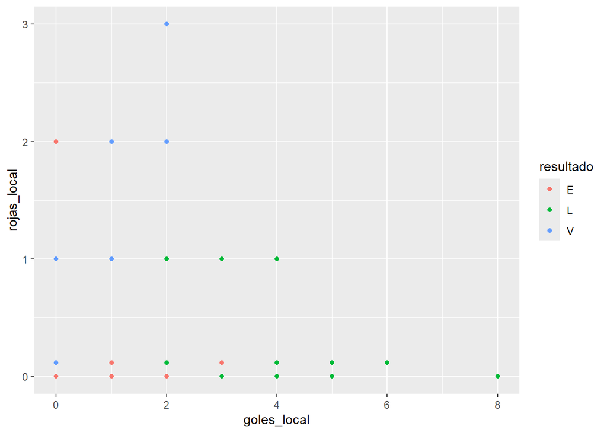

## Scatter plot: apuesta_local y posesion_local

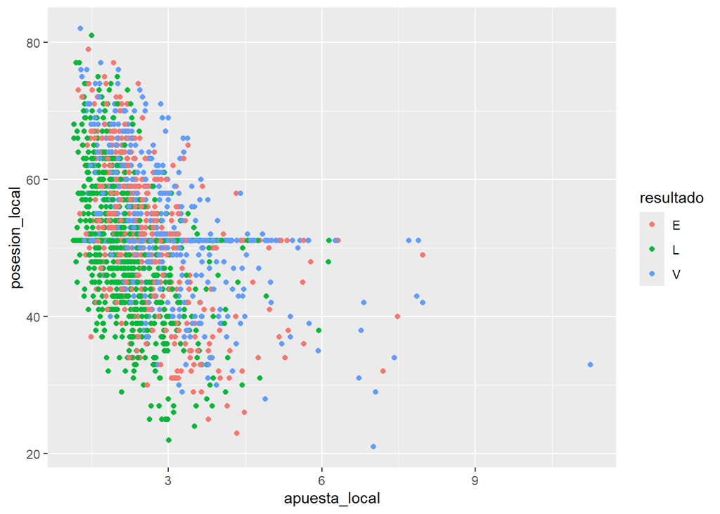

## Line plot: altura_media_local y posesion_local

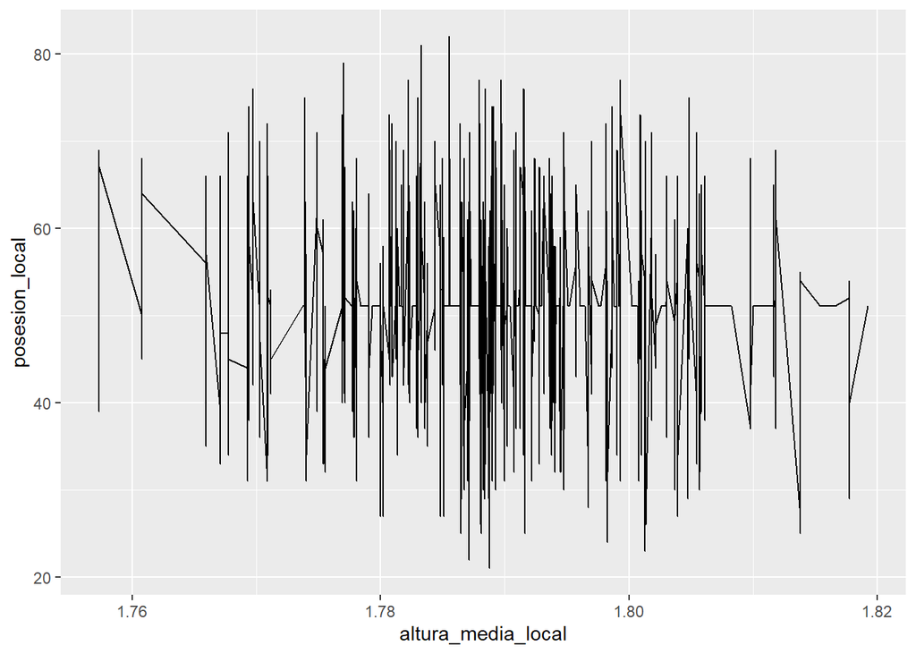

## Smooth plot: posesion_local y tiros_arco_local

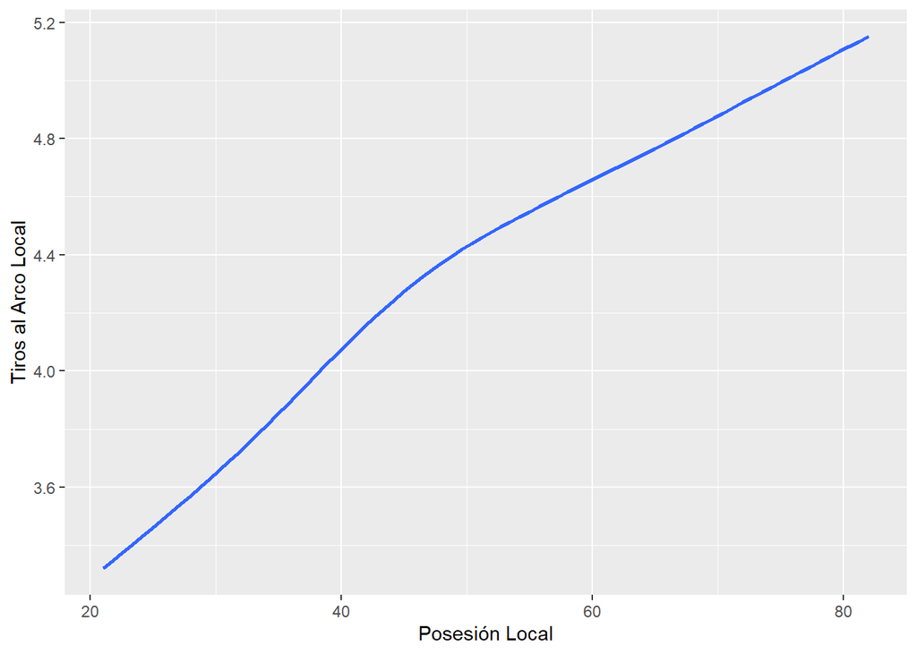

## Consideraciones

En este informe se manifiesta el trabajo efectuado para la sanitización y acondicionamiento del dataset de AFA 2015-2022, reemplazando valores faltantes con promedios, y hemos generado resúmenes y visualizaciones que ofrecen una visión general de los datos. Las técnicas empleadas pueden adaptarse y ampliarse para realizar análisis más detallados según sea necesario.

# Análisis PCA

Para interpretar los componentes principales (PC) con mayor impacto en el dataset utilizado, se deben observar los resultados del PCA, en particular, la varianza y las cargas (loadings) de cada PC. De estos, los que explican una mayor proporción de la varianza total del dataset, reflejan un mayor impacto. Además, las variables con mayores cargas absolutas en un PC, son las que más contribuyen a ese componente. En este informe, los dos primeros PC ofrecen una visión clara de las principales dimensiones del rendimiento de los equipos de fútbol Argentino. También nos ayudan a entender las principales variaciones en el rendimiento y pueden ser utilizados para comparar y planificar estrategias antes de los partidos.

# Interpretación de los Componentes Principales

## Primer Componente Principal (PC1)

El PC1 está dominado por variables relacionadas con las posesiones y los tiros al arco tanto del equipo local como del equipo visitante. Las variables como posesión local, tiros al arco local e intentos de gol del equipo local tienen cargas positivas altas en PC1, mientras que las mismas estadísticas para el equipo visitante tienen cargas negativas.

Esto sugiere que PC1 diferencia fuertemente entre el rendimiento del equipo local y el visitante. Un valor alto en PC1 podría interpretarse como un indicador de un mejor rendimiento del equipo local en términos de posesión y capacidad ofensiva, mientras que un valor bajo en PC1 podría indicar un mejor rendimiento del equipo visitante en estos mismos aspectos.

## Segundo Componente Principal (PC2)

```
## Importance of components:
##                           PC1    PC2    PC3    PC4     PC5     PC6     PC7
## Standard deviation     1.6263 1.2945 1.2019 0.9950 0.89611 0.87764 0.59124
## Proportion of Variance 0.2939 0.1862 0.1605 0.1100 0.08922 0.08558 0.03884
## Cumulative Proportion  0.2939 0.4800 0.6405 0.7505 0.83977 0.92535 0.96419
##                            PC8       PC9
## Standard deviation     0.56771 6.683e-16
## Proportion of Variance 0.03581 0.000e+00
## Cumulative Proportion  1.00000 1.000e+00
```

# Gráficos

## Sedimentación

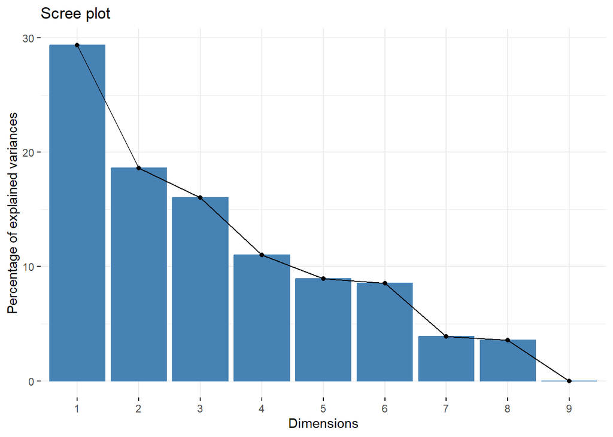

## Biplano

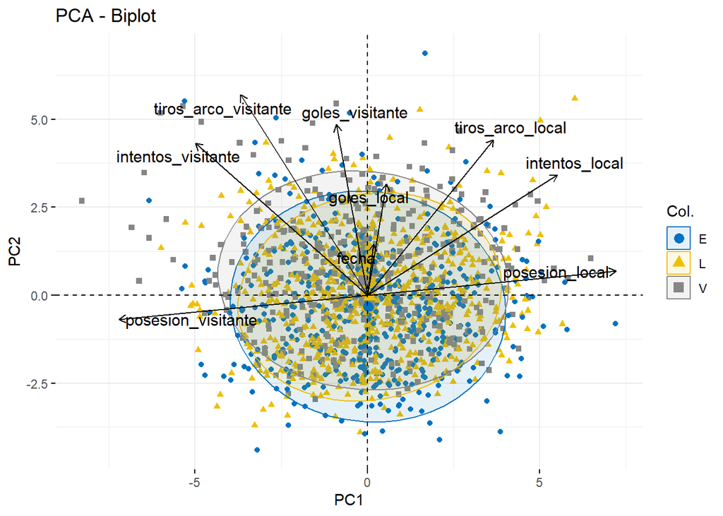

Este gráfico nos muestra los puntos que representan las observaciones del conjunto de datos proyectadas en el espacio de los primeros dos componentes principales y, vectores que representan las variables originales. La longitud y la dirección de estos indican cómo cada variable contribuye a los componentes principales y los clasifica por color según la variable cualitativa ‘resultado’ : ‘E’: Empate, ‘L’: Gana Local , y ‘V’: Gana Visitante.

# Cargas de los componentes principales

Las cargas de los componentes principales (loadings_reducido) representan la contribución de cada variable original a los componentes principales. Este análisis ayudará a entender qué variables tienen más influencia en la variabilidad capturada por cada componente principal.

```
##                              PC1         PC2        PC3          PC4
## fecha                 0.01278418  0.13253355  0.0378102  0.982859747
## goles_local           0.04056722  0.29048399  0.4786343 -0.146818304
## goles_visitante      -0.06617948  0.44479739 -0.3248662 -0.079258900
## posesion_local        0.52682213  0.06277588 -0.3703239 -0.018963773
## tiros_arco_local      0.26733211  0.40555833  0.4752796 -0.053666699
## intentos_local        0.40249596  0.31364681  0.2217803  0.009212067
## posesion_visitante   -0.52682213 -0.06277588  0.3703239  0.018963773
## tiros_arco_visitante -0.26894093  0.52200838 -0.3108336 -0.046615784
## intentos_visitante   -0.36459478  0.39621074 -0.1340418 -0.017084269
##                              PC5         PC6          PC7         PC8
## fecha                 0.09603226  0.07366684  0.001407433  0.01332472
## goles_local           0.72586487  0.27760499 -0.124010268 -0.20977149
## goles_visitante      -0.23330630  0.74562141  0.267917322 -0.06158499
## posesion_local        0.25094809 -0.09883990  0.076261353  0.04957946
## tiros_arco_local     -0.22336677 -0.13165748  0.269588118  0.62879331
## intentos_local       -0.45662264 -0.15739566 -0.253328349 -0.62681610
## posesion_visitante   -0.25094809  0.09883990 -0.076261353 -0.04957946
## tiros_arco_visitante  0.04204566 -0.20132975 -0.665532203  0.26674495
## intentos_visitante    0.15281196 -0.50929164  0.566940979 -0.29610317
##                                PC9
## fecha                -8.917352e-18
## goles_local          -1.030432e-16
## goles_visitante       3.495229e-16
## posesion_local       -7.071068e-01
## tiros_arco_local     -1.261903e-17
## intentos_local       -2.263114e-17
## posesion_visitante   -7.071068e-01
## tiros_arco_visitante -2.069745e-16
## intentos_visitante    1.827392e-16
```

## Visualización

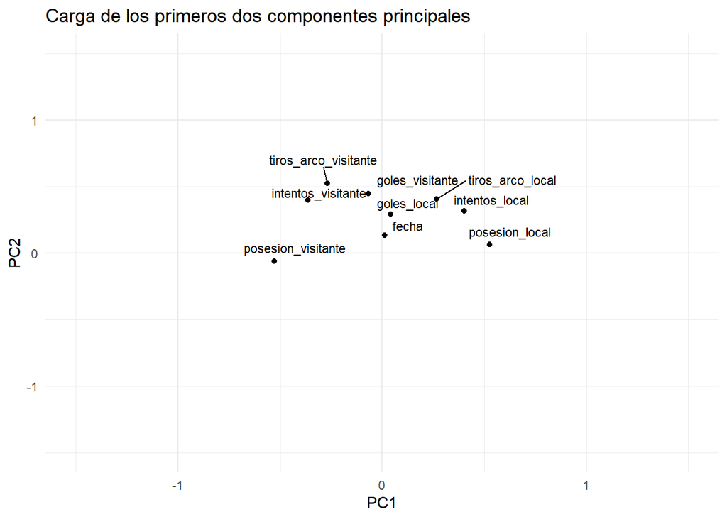

Valores de las Componentes Principales (PC1 y PC2)

| Variable | PC1 | PC2 |
| --- | --- | --- |
| posesion_local | 0.527 | NA |
| posesion_visitante | -0.527 | NA |
| intentos_local | 0.402 | NA |
| intentos_visitante | -0.365 | NA |
| tiros_arco_visitante | NA | 0.522 |
| goles_visitante | NA | 0.445 |
| goles_local | NA | 0.290 |

El PC1 está principalmente determinado por la posesión del equipo local y visitante y el número de intentos de ambos equipos. La posesión del equipo local tiene una carga positiva alta, mientras que la posesión del equipo visitante tiene una carga negativa alta, lo que sugiere que este componente captura la oposición entre la posesión de los equipos locales y visitantes.

# Observaciones finales

En los datos utilizados para este proyecto, es importante destacar , que también se detallan variables sobre las apuestas realizadas en cada partido de fútbol de cada campeonato entre el período de tiempo que se obtuvieron los datos del dataframe en cuestión. Estas no forman parte de la primera etapa de estudio porque quedaría pendiente para el desarrollo con modelos de machine learning, y de esa forma construir un proceso en el cual ingresan datos específicos de las variables elegidas para predecir si gana el partido el equipo local, por ejemplo. Haciendo referencia sobre características tácticas y/o estratégicas (porcentaje de posesión de pelota por partido), y también de eventos sucedidos con anterioridad (tiros al arco, por ejemplo). Sin embargo, existen posibilidades que sean útiles para caracterizar tipos de apuesta, relaciones ex-post con análisis por parte de los apostadores sobre los equipos, características estudiadas y otras. Y así contrastarlas con las salidas de un modelo predictivo. A si mismo, el análisis generado en este trabajo abre las puertas para profundizar la investigación haciendo foco en las ciencia de datos.

Volver al Índice